# 1 Introduction to Programming Languages

## 1. 编程与编程语言

1. 编程-编写程序
2. 程序：一系列对**数据**加工的**指令**
   - 管理学:为进行某项活动或过程所规定的途径
   - 途径——指令；数据加工——为进行某些活动
   - 开车：一踩二挂三转四呜五放六稳七抬
   - 计算机程序：(一系列指令的排列，这些指令用来操作计算机资源，比如内存、CPU、硬盘)
     - 计算机指令1
     - 计算机指令2
     - 计算机指令3
     - ......
3. 编程语言：**表示指令(和数据)的规则**
- 怎么编排这些指令呢？要有具体的规则，所以对语言的要求是不能有歧义（一条语句/指令表示多个意思)
- 自然语言就不行；自然语言要表示复杂的逻辑很困难说明白；计算机理解自然语言较为困难

**扩展1**：[为何编程语言大多不采用自然语言语法?](https://www.zhihu.com/question/498732425)

**扩展2**：NLP-Natural Language Processing - 人工智能的重要领域 - 让计算机理解人类的语言

4. 基础编程语言
- **机器语言** ：用0和1表示**指令**和**数据**
- **汇编语言** ：将机器码用符号(助记符)表示——增强了可读性；只是将机器码的指令/数据，用字符表示；**机器语言和汇编语言一一对应，所以汇编->机器码，只要用映射表，原封不懂替代一次即可**；这个步骤就称为**assembling**，完成这个步骤的程序就叫做**assembler**，这种代码就叫**assembly language**，ASM
- **高级语言** ：用类人类的语言来组织**指令**和**数据**；高级语言需要经过**编译(compile)/解释(Interpreter)**,最终生产二进制机器码；**高级语言和机器码不是一一对应的**(编译和汇编的工作不同，相当于对汇编/机器语言进行了一次封装，使得更易写出代码/基本上不在和硬件打交道，交给编译器完成和优化，汇编语言的指令基本上都是对寄存器的操作(不同的硬件平台指令都不一样))

**扩展3**: [用机器语言编程](https://www.bilibili.com/video/BV1Xh411X7Rk/?spm_id_from=333.337.search-card.all.click&vd_source=021b9a1c87445b18b831b989ef5e7d36)

- 机器语言

```
machine
1011 0000 0001 0001
0000 0100 0001 0100
1010 0010 0100 1000 0000 0000
```

- 汇编语言

```
MOV AL,17D
ADD AL,20D
MOV [SUM],AL
```

- 自然语言

```
SUM=17+20
```

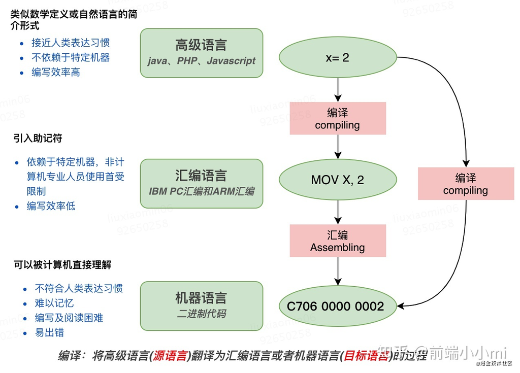

https://zhuanlan.zhihu.com/p/362072187

- 尝试理解 机器语言(机器码<->汇编) （8086CPU->8086指令集）

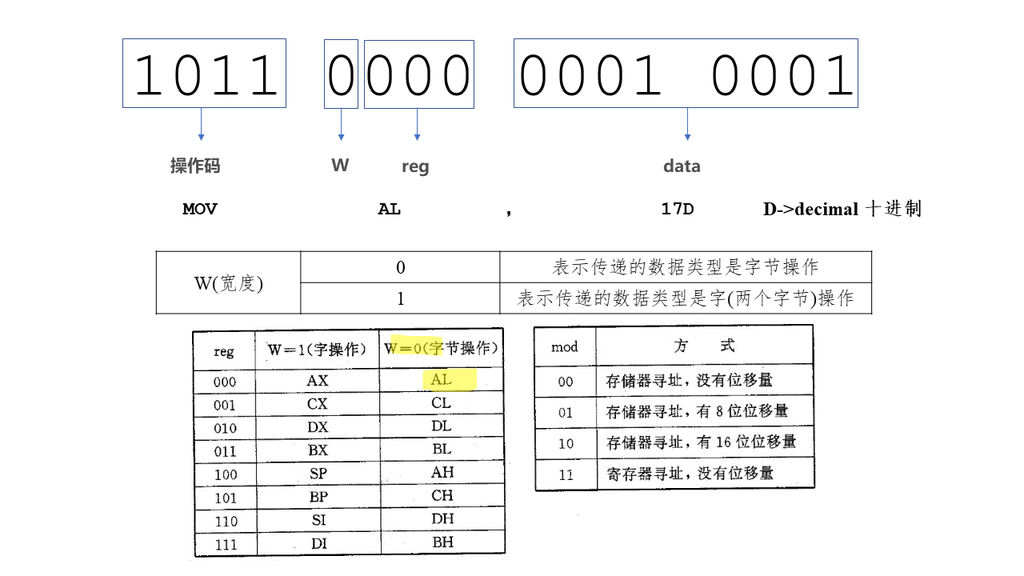

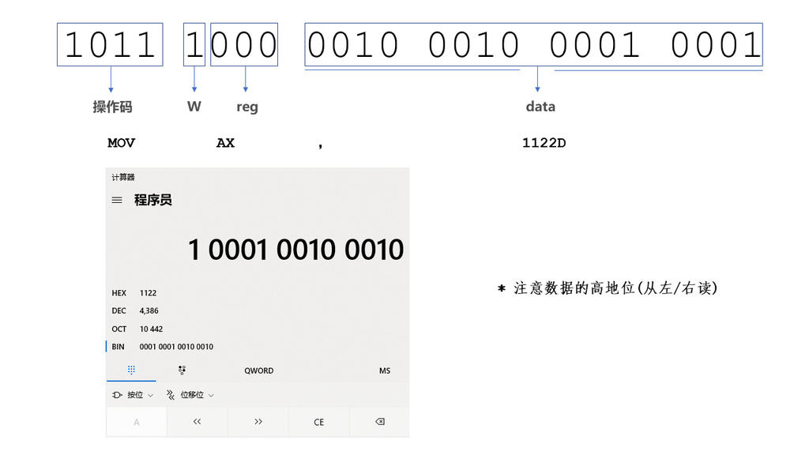

# 2 C语言简介

## 2.1 C语言应用场景

- 系统软件(驱动)-Linux系统
- 网络/服务器应用-Apache
- 各种文件处理软件-**Ffmpeg**、**OpenCV**
- 科研计算-lammps
- **嵌入式开发**-51单片机、STM32、[Arduino](https://www.bilibili.com/video/BV1ya411j7Yr/?vd_source=021b9a1c87445b18b831b989ef5e7d36)
- 界面开发-**QT**

## 2.2 About C

### 2.2.1 C语言编程一些基本概念

- 编程语言：**表示指令和数据的规则**
- 定义这些规则的人是谁？
  - 发明人:Dennis Ritchie,1978,贝尔实验室;《C Programming Language》Ken Thompson，Dennis Ritchie-> K&R C
  - 语言存在一些缺点，修改以及增强,不断发展->规则可能有调整和变化->要让使用者知道，相关开发人员了解->有权威性的人/机构来定义**标准**，变得更加通用
  - ANSI C(C89/90标准)，1990，C语言由美国国家标准协会（ANSI）进行了标准化
  - C99, 1999，ISO/IEC(国际标准化组织/ 国际电工委员会)
  - **扩展4**：[话语权和标准化](https://www.cnblogs.com/qiumingcheng/p/11339818.html)

#### 语言标准和语言功能的实现

- 我们的最终目的是利用代码实现某些功能；
- 语言标准 规定了我们 我们如何/怎么写代码(每个编码词的**意思/功能**以及如何组织这些编码词)，但是他不关心怎么**实现**具体的功能
- 高级语言要转换成机器码才能运行，编译器的作用就在此；
- 为什么 Windows、Linux、Mac OS / PC、服务器、单片机相同的代码都能运行(部分)相同的C代码呢，效果一样呢？
- 编译器针对不同的平台（硬件/操作系统），对同一个代码，针对不同的平台翻译成了不同的机器码；
- 所以C语言编译器有很多，Linux-> gcc/clang;Windows->msvc;各种单片机以及对应得编译器(都是不同的机构/个人/公司实现的)
- **扩展5**：[javascript和ECMA的关系](https://www.jianshu.com/p/10cfcb536d4a)

### 2.2.2 编译器工作原理

#### 编译器是如何读懂我们的代码的?**怎么**将其翻译机器读得懂得代码的？——《编译原理》

- **词法分析(Lexical analysis或/Scanning)** ：这个阶段的任务是从左到右一个字符一个字符地读入源程序，即对构成源程序的字符流进行扫描然后根据构词规则识别单词(也称单词符号或符号)。【分析词性：每个词属于名词？形容词？动词？介词…】
- **语法分析** ：分析各种介词短语、名词短语、动词短语…
- **语义分析** ：通过将语法展开成下图树的形式，可以最终根据根节点分析出整个句子的意思是什么。
- **扩展6** ：编译原理基本知识[(1)](https://zhuanlan.zhihu.com/p/362072187),[(2)](https://blog.csdn.net/cprimesplus/article/details/105724168)

[figure not shown]

### 2.2.3 C语言中的单词

#### Token：将识别的单词转换成统一的机内表示即词法单元，Token 是程序中对编译器有意义的最小元素

- 比如: **int,main,( ),{ },printf,return,"Hello World";** ,都是Token
- 每种单词都有各自的不同作用，人类语言中的名词、动词、形容词等
- Token的类型(C)

单词类型

说明

常见

Keywords 关键字

1. 每个关键字都意味着在程序中执行特定的功能
2. 关键字是编程语言中预先定义的或保留词(reserved word)
3. **关键字不能用作变量名；可以在编译前指定要替换关键字的文本**
4. C 语言支持的 **32** 种关键字
- 类型说明保留字(14):

**int,long,short,float,double,char,unsigned,signed,const,void,volatile,enum,struct,union**

- 语句定义保留字(13):

**if,else,goto,switch,case,do,while,for,continue,break,return,default,typedef**

- 存储类说明保留字(4):

**auto,register,extern,static**

- 长度运算符保留字(1):

**sizeof**

Identifiers 标志符

1. 标识符用作**变量、函数和数组命名**的通用术语
2. 这些是用户定义的名称，**由任意长的字母和数字序列组成，以字母或下划线(数字不行)作为第一个字符，不能有空格**
3. 不能和关键字同名
4. 最多31个字符
5. **一旦声明，就可以在以后的程序语句中使用标识符来引用关联的值**
- 帕斯卡(Pascal)命名法：

首字母和后面连接的每个单词的首字母都大写。**MyName**

- 骆驼(Camel)命名法:

将标识符的首字母小写，而每个后面连接的单词的首字母都大写。**myName**

- 匈牙利命名法:

以一个或者多个小写字母开头作为前缀；前缀之后的是首字母大写的一个单词或多个单词组合，该单词要指明变量的用途。**iMyName**

- UNIX命名法:

K&R命名法是所有标示符的字母小写，单词之间通过下划线分割。**my_name**

Constants 常量

1. 常数类似于一般的变量
2. **区别是，一旦定义了它们的值，程序就不能修改它们**
- #define
- const

Operators 运算符

运算符是一种告诉编译器执行特定的数学或逻辑操作的符号

运算符作用的数据项称为操作数。根据运算符可以作用的操作数，可以将运算符分类如下

- **一元运算符:**

一元减号 (-)，一元加号 (+)，增量 (++)，减量 (--)，逻辑否定 (!)，取地址(&)，取内容（*）

- **二元运算符:**
- 算术运算符

加（+）、减（-）、乘（*）、除（/）、求余（%）

- 关系运算符

大于（>）、小于（<）、等于（==）、大于等于（>=）、小于等于（<=）、不等于（!=）

- 逻辑运算符

逻辑与（&&）、逻辑或（||），非（!）

大于（>）、小于（<）、等于（==）、大于等于（>=）、小于等于（<=）、不等于（!=）

- 位运算符

位与（&）、位或（|）、位非（!）、位异或（^）、左移（<<）、右移（>>）

Special Symbol 特殊符号

C中使用的特殊符号，有一些特殊的含义，因此**不能用于其他目的**

- 方括号[]

左括号和右括号用作数组元素引用。这些表示单下标和多维下标。

- 括号（）

这些特殊符号用于指示函数调用和函数参数。

- 大括号 {}

这些开始和结束大括号标记包含多个可执行语句的代码块的开始和结束。

- 逗号 ，

用于分隔多个语句，如用于分隔函数调用中的参数。

- 分号 ；

表示语句结束

- 单引号 ''

表示单个字符，只能是单个字符

- 双引号 ""

表示字符串

- 预处理器 #

表示预处理指令

#### C语言关键字作用

| 数据类型关键字 | 基本类型 | char | 声明字符型变量或函数 |
| --- | --- | --- | --- |
|  |  | int | 声明整型变量或函数 |
|  |  | float | 声明浮点型变量或函数 |
|  |  | double | 声明双精度变量或函数 |
|  | 修饰类型 | short | 声明短整型变量或函数 |
|  |  | long | 声明长整型变量或函数 |
|  |  | signed | 声明有符号类型变量 |
|  |  | unsigned | 声明无符号类型变量 |
|  | 构造类型 | enum | 声明枚举类型 |
|  |  | union | 声明共用体（联合）数据类型 |
|  |  | struct | 声明结构体变量或函数 |
|  | 其他类型 | void | 声明万能（无类型）指针 |
| 控制语句关键字 | 循环语句 | for | 一种循环语句 |
|  |  | do | 循环语句的循环体 |
|  |  | while | 循环语句的循环条件 |
|  |  | break | 跳出当前循环 |
|  |  | continue | 结束当前循环，开始下一轮循环 |
|  | 条件语句 | if | 条件语句 |
|  |  | else | 条件语句否定分支（与if连用） |
|  |  | goto | 无条件跳转语句 |
|  | 开关语句 | switch | 用于开关语句 |
|  |  | case | 开关语句分支 |
|  |  | default | 开关语句中的“其他”分支 |
|  | 返回语句 | return | 子程序返回语句（可以带参数，也可不带参数） |
| 存储类型关键字 |  | auto | 声明自动变量 |
|  |  | extern | 声明变量是在其他文件正声明（也可以看做是引用变量） |
|  |  | register | 声明积存器变量 |
|  |  | static | 声明静态变量 |
| 其它关键字 |  | const | 声明只读变量 |
|  |  | sizeof | 计算数据类型长度 |
|  |  | typedef | 用以给数据类型取别名（当然还有其他作用) |
|  |  | volatile | 说明变量在程序执行中可被隐含地改变 |

## 2.3 分析Hello World程序

```
#include <stdio.h>
int main(){
    /*第一个C语言程序*/
    printf("Hello World!");
    return 0;
}
```

### 2.3.1 #include <stdio.h>

# include -> **预处理**关键字 ，作用 引入**外部文件/库**

- 这种引入方式很简单只是完全将 这一行代码，**替换成文件的原本内容**
- 这个替换的过程，是通过**预处理器**完成的；预处理过程一般只涉及源代码(.c)文件的组织，代码的替换，删除注释等，不涉及c语言的语法(编译的内容)；
  - 为了扩展C语言程序设计的环境，简化程序开发过程；
  - 有利于移植和调试C语言程序

#### C语言的(编译过程) 从 (**hello_world.c** 到 **hello_world.exe/.out**)

[figure not shown]

#### #include进一步认识

```
gcc -E Hello_World.c -o Hello_World.i # 生成预处理后的文件(一般以.i结尾)
```

- Hello_World.i

[output not shown]

- stdio.h

```
...
extern int __uflow (FILE *);
extern int __overflow (FILE *, int);

/* If we are compiling with optimizing read this file.  It contains
   several optimizing inline functions and macros.  */
#ifdef __USE_EXTERN_INLINES
# include <bits/stdio.h>
#endif
#if __USE_FORTIFY_LEVEL > 0 && defined __fortify_function
# include <bits/stdio2.h>
#endif
#ifdef __LDBL_COMPAT
# include <bits/stdio-ldbl.h>
#endif

__END_DECLS

#endif /* <stdio.h> included.  */
```

##### #include的使用

# include 的用法有两种，如下所示：

```
#include <stdHeader.h>
#include "myHeader.h"
```

- 使用尖括号 **< >** 和双引号 **" "** 的区别在于头文件的搜索路径不同:
- 使用尖括号 **< >** ，编译器会到系统路径下查找头文件;
- 而使用双引号 **" "** ，编译器首先在当前目录下查找头文件，如果没有找到，再到系统路径下查找,也可以使用**绝对路径**。
- 需要说明的是 常用的是 .h文件，但是这里只是一种习惯;这里只是文件名，什么文件名都行，只要内容符合C语言规则即可。

##### #include 路径问题

- 修改

```
#include </usr/include/stdio.h> /*Linux下的stdio.h文件的绝对路径*/
int main(){
    printf("Hello World-AbsPath");
    return 0;
}
```

- 再次测试是否能运行,一样能应用

```
gcc -E Hello_World_AbsPath.c -o Hello_World_AbsPath.i
```

##### #include 路径名测试

- Test_Include_Content.txt

```
#include <stdio.h>
int IncludeContent(){
    printf("Test Inlcude File");
    return 0;
}
```

- Test_Include_Main.c(主程序文件 main函数)

```
#include <stdio.h>
#include "Test_Include_Content.txt"
int main(){
    printf("Learn Include");
    IncludeContent();
    return 0;
}
```

- 编译，运行

```
gcc .\Test_Include_Main.c
.\a.exe
```

- 结果

```
Learn IncludeTest Inlcude File
```

##### 库文件

- **库(library)/包(package)/模块(module)** -- 提供了通用/自定义的/常用的/实现某种功能的函数的集合
- **stdio库：标准的输入输出库**

[output not shown]

### 2.3.2 int main(){}

1. "函数":函数是 **一组** 一起执行一个**任务**的语句

(接受数据然后返回结果/执行一系列动作-->目的本质上是对(输入)数据处理) 2. C语言是由**主函数**和若干**子函数**组成的，**C语言总是执行一个名字叫做 main 的函数** 3. C语言函数的写法：

```
return_type function_name( parameter list ) // 函数头
{
   body of the function
}
```

- **返回类型**：一个函数可以返回一个值。return_type 是函数返回的值的数据类型。有些函数执行所需的操作而不返回值，在这种情况下，return_type 是关键字 void。
- **函数名称**：这是函数的实际名称。函数名和参数列表一起构成了函数签名。
- **参数**：参数就像是占位符。当函数被调用时，您向参数传递一个值，这个值被称为实际参数。参数列表包括函数参数的类型、顺序、数量。参数是可选的，也就是说，函数可能不包含参数。
- **函数主体**：函数主体包含一组定义函数执行任务的语句。

### 2.3.3 return

1. (只)用在函数体中
2. 表示函数结束--> 函数中 return语句 以后的语句不再执行
3. 从函数中返回一条 return_type 的数据
4. **函数调用**过程，可以拿到这个返回值(函数处理后的值)

```
return_type function_name( parameter list ) // 函数头
{
   body of the function
       ...
   return XXXXX;  // XXXX 的 数据类型为 return_type
}
```

#### 一个简单的例子

```
#include <stdio.h>

// 函数定义
void SayHi(){
    printf("Hi! Function!");
    return;
}

void main(){
    printf("AAAAA");
    SayHi(); // 函数调用
    return ;
}
```

### 2.3.4 printf("Hello World!");

- prinf 是一个函数，定义在 stdio库中

```
// stdio.h
...
...
int printf (const char *__format, ...)
{
  register int __retval;
  __builtin_va_list __local_argv; __builtin_va_start( __local_argv, __format );
  __retval = __mingw_vprintf( __format, __local_argv );
  __builtin_va_end( __local_argv );
  return __retval;
}
...
```

- 调用函数：函数名(参数);/ 变量=函数名(参数)；->接收函数的返回值
- 回顾：main函数是自动执行(系统自动调用的)。

Notes：后续：怎么写自己的工具库